# Régression multiple

Bruno Langlois

2025-11-11

## 1 $-$ Introduction

Le jeu de données **Student Exam Score** contient des informations sur 200 étudiants dont leurs performances aux évaluations. Les variables incluses sont :

`study_hours` : nombre d’heures d’étude consacrées par l’étudiant.

`sleep_hours` : nombre d’heures de sommeil par nuit.

`attendance_percentage` : assiduité (pourcentage de présence en cours).

`previous_score` : score (sur 100) obtenu à l’examen précédent.

`final_score` : score (sur 100) obtenu à l’examen actuel (variable à expliquer).

Chaque ligne correspond à un étudiant différent. Ce dataset permet d’analyser comment différents facteurs liés au comportement et à la préparation influencent la performance à l’examen.

L’objectif principal de cette analyse est de modéliser le score final (`final_score`) des étudiants en fonction de plusieurs facteurs explicatifs. Plus précisément, nous chercherons à :

- Explorer graphiquement et statistiquement les relations entre le score final et les variables explicatives (`study_hours`, `sleep_hours`, `attendance_percentage` et `previous_score`).
- Ajuster un modèle de régression linéaire multiple afin de prédire le score final à partir de ces facteurs.
- Évaluer la qualité du modèle (R², ajustement, significativité des coefficients) et identifier les variables les plus influentes.

Cette analyse permettra de mieux comprendre comment différents aspects de la préparation et du comportement étudiant influencent les performances à un examen, et de prédire, de manière statistique, les résultats à partir de données observables.

⚠️ Dans un but pédagogique, nous introduirons artificiellement deux variables “intruses”.

##### **■ Chargement du dataset Student Exam Score**

```r
library(readr)
url <- "https://raw.githubusercontent.com/datablang/learning-statistics-with-R/main/student_exam_scores.csv"
ses <- read_csv(url,show_col_types = FALSE)
```

## 2 $-$ Exploration des données

```r
spec(ses) # nom et type des variables
ses <- ses[, -1] # élimination de la colonne contenant l'identifiant
names(ses) <- c("study", "sleep", "attend", "prev", "exam") # raccourcissement du nom des variables
set.seed(123)  # pour la reproductibilité
ses$study2 <- -0.6*ses$study  + rnorm(nrow(ses), mean = 0, sd = 1)/2 # nouvelle variable très corrélée à study
ses$noise <- rnorm(nrow(ses), mean = 0, sd = 1)  # ajout d'un petit bruit indépendant
ses <- ses[, c("study", "sleep", "attend", "prev", "study2", "noise", "exam")]
```

Raccourcissement du nom des variables :

`study_hours` → `study`  
`sleep_hours` → `sleep`  
`attendance_percentage` → `attend`  
`previous_score` → `prev`  
`final_score` → `exam`

et création de deux nouvelles variables :

`study2` : très corrélée à `study`

`noise` : constituée de “bruit” et qui n’explique rien

```r
head(ses) # les premières lignes
```

```
## # A tibble: 6 × 7
##   study sleep attend  prev study2  noise  exam
##   <dbl> <dbl>  <dbl> <dbl>  <dbl>  <dbl> <dbl>
## 1   8     8.8   72.1    45 -5.08   2.20   30.2
## 2   1.3   8.6   60.7    55 -0.895  1.31   25
## 3   4     8.2   73.7    86 -1.62  -0.265  35.8
## 4   3.5   4.8   95.1    66 -2.06   0.543  34
## 5   9.1   6.4   89.8    71 -5.40  -0.414  40.3
## 6   8.4   5.1   58.5    75 -4.18  -0.476  35.7
```

```r
summary(ses) # résumé statistique
```

```
##      study            sleep           attend            prev
##  Min.   : 1.000   Min.   :4.000   Min.   : 50.30   Min.   :40.0
##  1st Qu.: 3.500   1st Qu.:5.300   1st Qu.: 62.20   1st Qu.:54.0
##  Median : 6.150   Median :6.700   Median : 75.25   Median :67.5
##  Mean   : 6.325   Mean   :6.622   Mean   : 74.83   Mean   :66.8
##  3rd Qu.: 9.000   3rd Qu.:8.025   3rd Qu.: 87.42   3rd Qu.:80.0
##  Max.   :12.000   Max.   :9.000   Max.   :100.00   Max.   :95.0
##      study2            noise               exam
##  Min.   :-7.9946   Min.   :-2.46590   Min.   :17.10
##  1st Qu.:-5.3083   1st Qu.:-0.59077   1st Qu.:29.50
##  Median :-3.7613   Median : 0.02283   Median :34.05
##  Mean   :-3.7996   Mean   : 0.04212   Mean   :33.95
##  3rd Qu.:-2.1583   3rd Qu.: 0.71482   3rd Qu.:38.75
##  Max.   : 0.3219   Max.   : 2.57146   Max.   :51.30
```

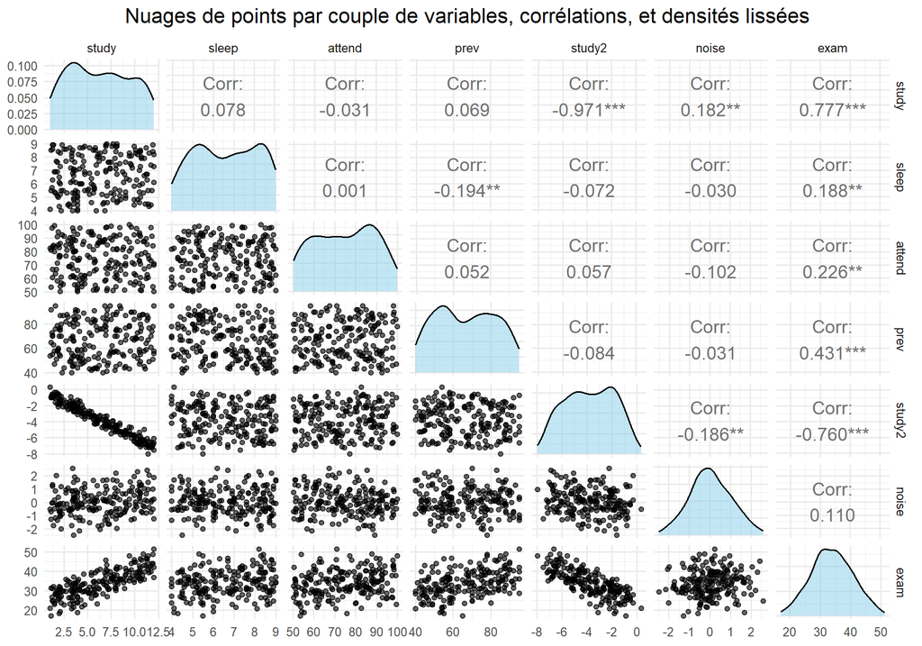

```r
library(ggplot2)
library(GGally)
# un nuage de points pour chaque paire de variables :
ggpairs(
  ses,
  lower = list(continuous = wrap("points", alpha = 0.6, size = 1.5)),   # nuages de points semi-transparents
  upper = list(continuous = wrap("cor", size = 5)),                     # corrélation en haut
  diag  = list(continuous = wrap("densityDiag", fill = "skyblue", alpha = 0.5)) # densités lissées diagonale
) +
  ggtitle("Nuages de points par couple de variables, corrélations, et densités lissées") +
  theme(plot.title = element_text(hjust = 0.5, margin = margin(b = 10))) +
  theme_minimal(base_size = 12) +
  theme(plot.title = element_text(hjust = 0.5)) + # titre centré
  theme(plot.title = element_text(hjust = 0.5, size = 16))  # taille et gras
```

La corrélation correspondant au couple (`study`,`study2`), égale à -0.971, est très proche de -1. On peut d’ores et déjà soupçonner la présence de colinéarité.

## 3 $-$ Régression linéaire multiple

#### ■ Estimation des paramètres du modèle complet

```r
reg1 <- lm(exam~., data=ses)
summary(reg1)
```

```
##
## Call:
## lm(formula = exam ~ ., data = ses)
##
## Residuals:
##     Min      1Q  Median      3Q     Max
## -5.2882 -2.0847 -0.0215  2.2517  4.7623
##
## Coefficients:
##             Estimate Std. Error t value Pr(>|t|)
## (Intercept) -2.29336    1.68109  -1.364    0.174
## study        1.33524    0.25248   5.288 3.33e-07 ***
## sleep        0.95662    0.13291   7.197 1.33e-11 ***
## attend       0.11058    0.01380   8.015 1.03e-13 ***
## prev         0.17684    0.01275  13.871  < 2e-16 ***
## study2      -0.36191    0.41654  -0.869    0.386
## noise        0.12055    0.19967   0.604    0.547
## ---
## Signif. codes:  0 '***' 0.001 '**' 0.01 '*' 0.05 '.' 0.1 ' ' 1
##
## Residual standard error: 2.737 on 193 degrees of freedom
## Multiple R-squared:  0.8424, Adjusted R-squared:  0.8375
## F-statistic: 171.9 on 6 and 193 DF,  p-value: < 2.2e-16
```

Le test de significativité globale du modèle, qui met à l’épreuve l’hypothèse

$$H_0 : \beta_{\text{study}} =
\beta_{\text{sleep}} = \beta_{\text{attend}} = \beta_{\text{prev}}
=\beta_{\text{study2}}=\beta_{\text{noise}} = 0$$

conduit à une p-value inférieure à 2.2e-16 et donc largement en deçà du seuil de 5%. On rejette donc $H_0$, ce qui implique qu’au moins une variable explicative a un effet significatif sur la note finale.

Les tests de significativité individuels des paramètres associés aux variables `study`, `sleep`, `attend` et `prev` (l’hypothèse nulle consistant à supposer que le paramètre en question est nul) conduisent tous à une p-value négligeable, très inférieure au seuil de 5%. On rejette donc les hypothèses correspondantes et on conclut que chacune des 4 variables précédentes a une influence significative sur la note finale à l’examen.

Le coefficient de détermination R² = 0,8424 indique que le modèle explique environ 84 % de la variabilité de la note finale, ce qui traduit une excellente qualité d’ajustement.

Les variables `study2` et `noise` n’exercent pas d’effet significatif sur la note finale, ce qui était attendu pour ces variables ajoutées artificiellement.

## 4 $-$ Diagnostic de colinéarité

Nous allons tenter de confirmer le soupçon de colinéarité entre les variables `study` et `study2` (corrélation égale à -0.971), en utilisant le facteur d’inflation de la variance (VIF) :

```r
library(carData)
library(car)
vif(reg1)
```

```
##     study     sleep    attend      prev    study2     noise
## 17.635157  1.051682  1.026594  1.059139 17.729709  1.050317
```

Comme on pouvait s’y attendre, on constate que VIF(`study`) et VIF(`study2`) dépassent nettement le seuil de 3, ce qui est généralement considéré comme le signe d’une colinéarité notable.

Les conditions index vont également dans ce sens :

```r
library(olsrr)
round(ols_eigen_cindex(reg1), 2)
```

```
##   Eigenvalue Condition Index intercept study sleep attend prev study2 noise
## 1       5.61            1.00      0.00  0.00  0.00   0.00 0.00   0.00  0.00
## 2       1.01            2.36      0.00  0.00  0.00   0.00 0.00   0.00  0.92
## 3       0.27            4.55      0.00  0.01  0.01   0.01 0.01   0.01  0.07
## 4       0.06            9.67      0.00  0.00  0.38   0.00 0.41   0.00  0.00
## 5       0.03           12.67      0.00  0.00  0.25   0.60 0.27   0.00  0.00
## 6       0.01           23.65      0.99  0.00  0.36   0.36 0.30   0.00  0.01
## 7       0.01           30.74      0.01  0.98  0.00   0.03 0.00   0.98  0.00
```

En effet, on observe que la plus petite valeur propre (λ ≃ 0.01) présente un condition index supérieur à 30, ce qui est un indice sérieux de présence de multicolinéarité. En observant les proportions de variation associées à cette valeur propre, on remarque que celles de `study` et `study2` sont très élevées (0.98 dans les deux cas), ce qui valide l’hypothèse d’une colinéarité entre ces deux variables.

## 5 $-$ Sélection des variables

Dans notre dataset, on a 6 variables explicatives, c’est suffisamment peu pour pouvoir effectuer une sélection exhaustive (en anglais, cette procédure est baptisée *best subset regression*). Après avoir ajusté tous les sous-modèles, on affiche le modèle le mieux ajusté avec une variable, puis avec deux variables, puis avec trois variables explicatives, etc. :

```r
# Exécuter la recherche exhaustive
resultats <- ols_step_best_subset(reg1)
# Extraireet afficher la liste des sous-modèles
sous_modeles <- resultats$metrics$predictors
print(sous_modeles)
```

```
## [1] "study"
## [2] "study prev"
## [3] "study attend prev"
## [4] "study sleep attend prev"
## [5] "study sleep attend prev study2"
## [6] "study sleep attend prev study2 noise"
```

Ensuite on compare ces modèles optimaux en utilisant plusieurs critères :

```r
# Extraire le data frame "metrics"
metrics_df <- resultats$metrics
# Sélectionner uniquement les colonnes souhaitées
resultats_final <- metrics_df[, c("adjr", "predrsq", "cp", "aic")]
# Renommer les colonnes pour plus de clarté
colnames(resultats_final) <- c("Adj. R-Square", "Pred R-Square", "C(p)", "AIC")
# Afficher les résultats
print(resultats_final)
```

```
##   Adj. R-Square Pred R-Square       C(p)       AIC
## 1     0.6013395     0.5954908 289.655269 1153.7901
## 2     0.7439193     0.7388206 116.386470 1066.2539
## 3     0.7963034     0.7906999  53.640204 1021.4639
## 4     0.8381712     0.8329421   4.155734  976.4224
## 5     0.8379999     0.8319277   5.364494  977.6057
## 6     0.8374675     0.8301436   7.000000  979.2283
```

On observe que selon tous les critères, le meilleur modèle est celui à 4 prédicteurs : `study`, `sleep`, `attend` et `prev`.

On peut également effectuer une régression pas à pas descendante (en anglais, *backward elimination*), méthode moins gourmande en calcul que la sélection exhaustive. À titre d’exemple, appliquons-la en utilisant l’AIC (Akaike Information Criterion) comme critère : à chaque étape, on retire la variable dont la suppression améliore le plus le modèle, tant que l’AIC du modèle réduit reste inférieure à celle du modèle complet. Le processus s’arrête dès qu’aucune suppression ne permet d’abaisser davantage l’AIC.

```r
ols_step_backward_aic(model = reg1, detail = T)
```

```
## Backward Elimination Method
## ---------------------------
##
## Candidate Terms:
##
## 1. study
## 2. sleep
## 3. attend
## 4. prev
## 5. study2
## 6. noise
##
##
## Step     => 0
## Model    => exam ~ study + sleep + attend + prev + study2 + noise
## AIC      => 979.2283
##
## Initiating stepwise selection...
##
##                    Table: Removing Existing Variables
## ------------------------------------------------------------------------
## Predictor    DF      AIC         SBC        SBIC        R2       Adj. R2
## ------------------------------------------------------------------------
## noise         1     977.606    1000.694    410.440    0.84207    0.83800
## study2        1     978.009    1001.097    410.818    0.84175    0.83767
## study         1    1004.293    1027.382    435.561    0.81953    0.81487
## sleep         1    1024.780    1047.869    454.942    0.80006    0.79491
## attend        1    1034.692    1057.780    464.347    0.78990    0.78449
## prev          1    1115.552    1138.640    541.740    0.68522    0.67711
## ------------------------------------------------------------------------
##
## Step     => 1
## Removed  => noise
## Model    => exam ~ study + sleep + attend + prev + study2
## AIC      => 977.6057
##
##                    Table: Removing Existing Variables
## ------------------------------------------------------------------------
## Predictor    DF      AIC         SBC        SBIC        R2       Adj. R2
## ------------------------------------------------------------------------
```

[output cut: 14 more lines]

```
## Predictor    DF      AIC         SBC        SBIC        R2       Adj. R2
## ------------------------------------------------------------------------
## sleep         1    1021.464    1037.955    452.333    0.79937    0.79630
## attend        1    1030.705    1047.197    461.250    0.78989    0.78667
## prev          1    1113.495    1129.986    541.558    0.68215    0.67728
## study         1    1270.547    1287.039    695.674    0.30295    0.29228
## ------------------------------------------------------------------------
##
##
## No more variables to be removed.
##
## Variables Removed:
##
## => noise
## => study2
```

```
##
##
##                               Stepwise Summary
## --------------------------------------------------------------------------
## Step    Variable        AIC        SBC        SBIC        R2       Adj. R2
## --------------------------------------------------------------------------
##  0      Full Model    979.228    1005.615    412.158    0.84237    0.83747
##  1      noise         977.606    1000.694    410.399    0.84207    0.83800
##  2      study2        976.422     996.212    409.102    0.84142    0.83817
## --------------------------------------------------------------------------
##
## Final Model Output
## ------------------
##
##                          Model Summary
## ---------------------------------------------------------------
## R                       0.917       RMSE                 2.697
## R-Squared               0.841       MSE                  7.273
## Adj. R-Squared          0.838       Coef. Var            8.044
## Pred R-Squared          0.833       AIC                976.422
## MAE                     2.287       SBC                996.212
## ---------------------------------------------------------------
##  RMSE: Root Mean Square Error
##  MSE: Mean Square Error
##  MAE: Mean Absolute Error
##  AIC: Akaike Information Criteria
##  SBC: Schwarz Bayesian Criteria
##
##                                 ANOVA
## ----------------------------------------------------------------------
##                 Sum of
##                Squares         DF    Mean Square       F         Sig.
## ----------------------------------------------------------------------
## Regression    7718.799          4       1929.700    258.674    0.0000
## Residual      1454.696        195          7.460
## Total         9173.495        199
## ----------------------------------------------------------------------
##
##                                   Parameter Estimates
## ---------------------------------------------------------------------------------------
##       model      Beta    Std. Error    Std. Beta      t        Sig      lower    upper
## ---------------------------------------------------------------------------------------
## (Intercept)    -2.142         1.671                 -1.282    0.201    -5.437    1.153
##       study     1.555         0.060        0.739    25.732    0.000     1.436    1.674
##       sleep     0.952         0.132        0.210     7.191    0.000     0.691    1.213
##      attend     0.108         0.014        0.227     7.961    0.000     0.082    0.135
##        prev     0.177         0.013        0.409    13.995    0.000     0.152    0.202
## ---------------------------------------------------------------------------------------
```

On constate que le sous-modèle retenu avec cette méthode est le même qu’avec la sélection exhaustive.

## 6 $-$ Validation du modèle réduit

Ici, nous avons effectué une sélection exhaustive, et le modèle réduit optimal est celui obtenu en retirant du modèle complet les deux variables dont les paramètres n’étaient pas significatifs. Dans ce contexte, les p-values issues du test des modèles emboîtés réduit/complet — comme celles de la régression du modèle réduit — peuvent être optimistes, car le modèle a été choisi après avoir observé les données.  
Nous allons néanmoins les présenter, mais il faudra interpréter ces diagnostics avec prudence.

```r
# Modèle réduit (remplace par tes variables retenues)
reg2 <- lm(exam ~ study + sleep + attend + prev, data = ses)
summary(reg2)
```

```
##
## Call:
## lm(formula = exam ~ study + sleep + attend + prev, data = ses)
##
## Residuals:
##     Min      1Q  Median      3Q     Max
## -5.5455 -2.1818 -0.0847  2.3436  4.8390
##
## Coefficients:
##             Estimate Std. Error t value Pr(>|t|)
## (Intercept) -2.14209    1.67079  -1.282    0.201
## study        1.55526    0.06044  25.732  < 2e-16 ***
## sleep        0.95226    0.13243   7.191 1.34e-11 ***
## attend       0.10839    0.01362   7.961 1.38e-13 ***
## prev         0.17728    0.01267  13.995  < 2e-16 ***
## ---
## Signif. codes:  0 '***' 0.001 '**' 0.01 '*' 0.05 '.' 0.1 ' ' 1
##
## Residual standard error: 2.731 on 195 degrees of freedom
## Multiple R-squared:  0.8414, Adjusted R-squared:  0.8382
## F-statistic: 258.7 on 4 and 195 DF,  p-value: < 2.2e-16
```

```r
# Test F des modèles emboîtés
anova(reg2, reg1)
```

```
## Analysis of Variance Table
##
## Model 1: exam ~ study + sleep + attend + prev
## Model 2: exam ~ study + sleep + attend + prev + study2 + noise
##   Res.Df    RSS Df Sum of Sq      F Pr(>F)
## 1    195 1454.7
## 2    193 1446.0  2    8.6592 0.5779 0.5621
```

Sans surprise, les p-values issues de la régression du modèle réduit sont très faibles, ce qui suggère que les variables conservées expliquent bien la réponse.

Le test des modèles emboîtés, qui met à l’épreuve l’hypothèse

$$H_0 :
\beta_{\text{study2}}=\beta_{\text{noise}}=0$$

donne une p-value de 0.5621, donc largement supérieure au seuil de 5%. On ne peut donc pas rejeter $H_0$, ce qui confirme que les deux variables retirées n’apportaient aucune information utile.

## 7 $-$ Diagnostic des résultats de régression

#### ■ Analyse des résidus

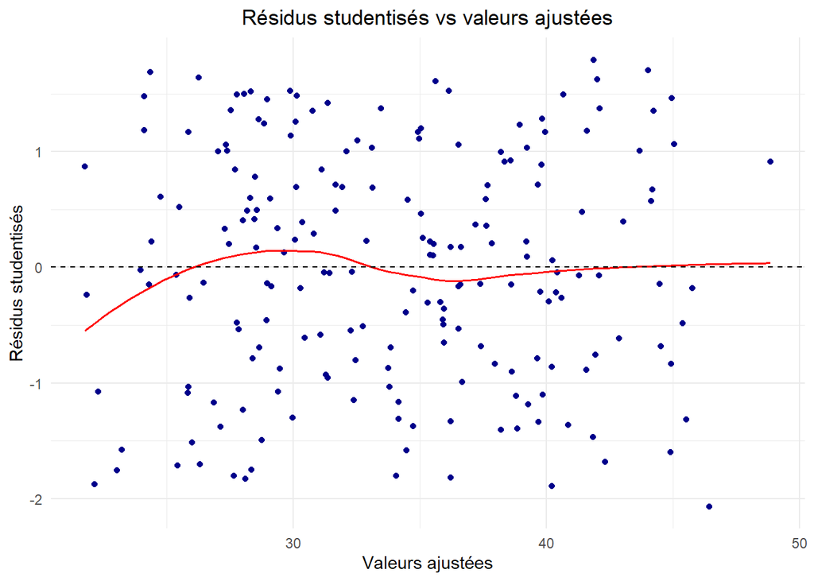

```r
library(broom)
# Extraire les résidus studentisés et valeurs ajustées
df_diag <- augment(reg2)  # contient .fitted et .std.resid
# Graphique résidus studentisés vs valeurs ajustées
ggplot(df_diag, aes(x = .fitted, y = .std.resid)) +
  geom_point(color = "darkblue") +                       # points
  geom_smooth(method = "loess", se = FALSE, color = "red", formula = y ~ x, linewidth = 0.6) + # courbe lisse
  geom_hline(yintercept = 0, linetype = "dashed") +     # ligne 0
  labs(
    x = "Valeurs ajustées",
    y = "Résidus studentisés",
    title = "Résidus studentisés vs valeurs ajustées"
  ) +
  theme_minimal() +
  theme(plot.title = element_text(hjust = 0.5))  # centre le titre
```

Le graphique ne montre aucune structure particulière dans les résidus. La dispersion semble aléatoire et homogène, ce qui va dans le sens des hypothèses d’homoscédasticité et de linéarité. La courbe de tendance reste proche de zéro ; une légère courbure apparaît mais ne remet pas en cause le modèle.

Effectuons le test de Durbin-Watson pour vérifier l’indépendance des résidus au sens de l’absence d’autocorrélation.

```r
durbinWatsonTest(reg2)
```

```
##  lag Autocorrelation D-W Statistic p-value
##    1     -0.03047921      2.034282   0.826
##  Alternative hypothesis: rho != 0
```

Ce test met à l’épreuve l’hypothèse nulle d’absence d’autocorrélation des erreurs. Il donne une p-value de 0.826, très largement supérieure au seuil de 5%, donc on ne rejette pas cette hypothèse et on conclut à l’absence d’autocorrélation.

Cependant, ce test est conçu pour des données ordonnées dans le temps ; dans notre cas, les observations sont indépendantes les unes des autres, et l’usage de ce test n’est donc pas forcément pertinent dans notre contexte.

On peut aussi tester aussi l’hypothèse nulle d’homoscédasticité grâce au test de Breusch-Pagan (dans la version proposée par Koenker, robuste à une éventuelle violation de l’hypothèse de normalité des erreurs).

```r
library(zoo)
library(lmtest)
bptest(reg2)
```

```
##
##  studentized Breusch-Pagan test
##
## data:  reg2
## BP = 0.9069, df = 4, p-value = 0.9236
```

La p-value associée au test, égale à 0.9236, est très largement supérieure au seuil de 5%, par conséquent, on ne rejette pas l’hypothèse d’homoscédasticité : rien n’indique une variance non constante des erreurs.

Passons maintenant au contrôle de la normalité des résidus en commençant par tracer le diagramme quantile-quantile (QQ-plot) qui compare les quantiles des résidus observés à ceux d’une loi normale.

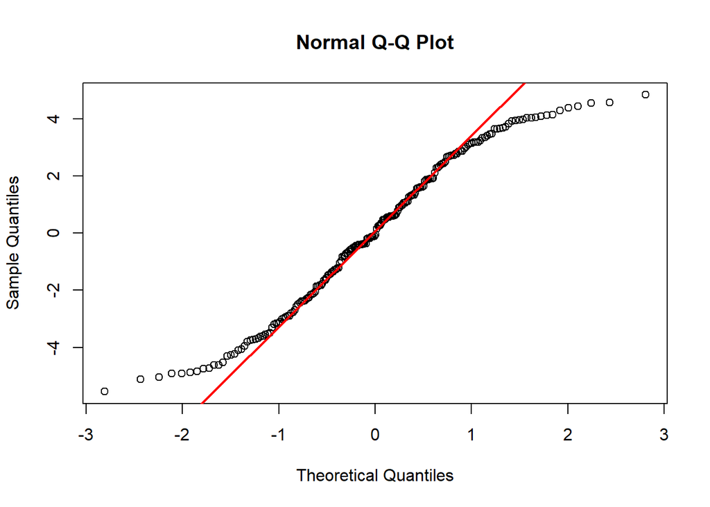

```r
# Extraire les résidus
residus <- resid(reg2)
# QQ-plot classique
qqnorm(residus)
qqline(residus, col = "red", lwd = 2)
```

Environ 85% des points sont globalement alignés sur la droite de référence, cependant les queues de distribution sont “lourdes”, ce qui peut pourrait signifier une violation de l’hypothèse de normalité des erreurs.

Pour le confirmer, nous allons effectuer le test de Shapiro-Wilk, qui met à l’épreuve l’hypothèse nulle de normalité des erreurs.

```r
shapiro.test(reg2$residuals)
```

```
##
##  Shapiro-Wilk normality test
##
## data:  reg2$residuals
## W = 0.96664, p-value = 0.0001112
```

La p-value associée au test est égale à 0.0001112 << 0.05, ce qui conduit au rejet de l’hypothèse de normalité des erreurs. Étant donné la taille de l’échantillon, les estimateurs restent fiables, mais il convient d’interpréter le modèle avec prudence, en gardant à l’esprit que les intervalles de confiance et les tests de significativité peuvent être affectés par une non-normalité.

#### ■ Détection des points aberrants et influents

Commençons par tracer le graphique des leviers.

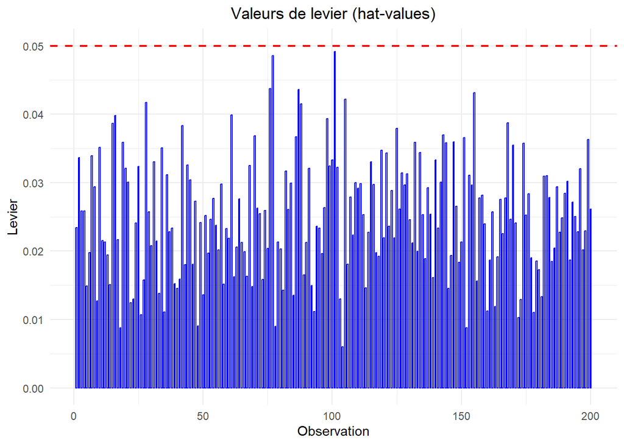

```r
df_diag <- augment(reg2)
# Seuil de levier
seuil_levier <- 2 * length(coefficients(reg2)) / nrow(df_diag)

ggplot(df_diag, aes(x = seq_along(.hat), y = .hat)) +
  geom_col(width = 0.5, colour = "blue", fill = NA) +
  geom_hline(yintercept = seuil_levier, colour = "red", linewidth = 0.8, linetype = "dashed") +

  # Étiquette seulement pour les points au-dessus du seuil
  geom_text(
    data = subset(df_diag, .hat > seuil_levier),
    aes(label = rownames(ses)[.hat > seuil_levier]),
    vjust = -0.6,
    size = 3
  ) +

  labs(
    x = "Observation",
    y = "Levier",
    title = "Valeurs de levier (hat-values)"
  ) +
  theme_minimal() +
  theme(plot.title = element_text(hjust = 0.5))
```

Aucun levier ne dépasse le seuil habituellement fixé à $\dfrac{2(p+1)}{n}$ (ici avec p = 4 et n = 200), soit 0.05. Aucune observation ne semble donc exercer une influence excessive sur l’estimation des coefficients.

Poursuivons avec le diagramme de la distance de Cook.

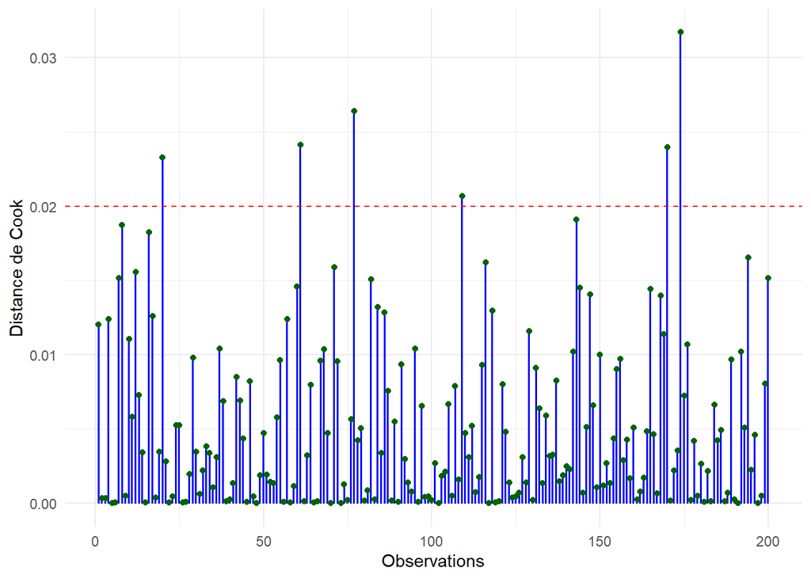

```r
# Calculer les distances de Cook
cooks <- cooks.distance(reg2)
n <- nrow(ses)
seuil <- 4/n
# Diagramme ggplot sans incrustation automatique
ggplot(data.frame(obs = seq_along(cooks), cooks = cooks), aes(x = obs, y = cooks)) +
  geom_col(width = 0.1, colour = "blue") +              # les barres
  geom_point(colour = "darkgreen", size = 1.5) +          # les petits ronds
  geom_hline(yintercept = seuil, colour = "red", linetype = "dashed") +
  labs(x = "Observations", y = "Distance de Cook") +
  theme_minimal()
```

Six observations présentent une distance de Cook supérieure au seuil très conservatif de 4/n. Toutefois, leurs valeurs restent nettement inférieures au seuil usuel de 1, ce qui indique qu’aucune observation ne peut être considérée comme réellement influente sur l’estimation des coefficients.

## 8 $-$ Conclusion

Le diagnostic du modèle de régression complet révèle l’influence d’au moins une des six variables explicatives sur la variable `exam`. Seules les estimations des paramètres des deux variables ajoutées artificiellement (`study2` et `noise`) s’évèrent non significatives. Une sélection exhaustive aboutit précisément au modèle réduit obtenu en privant le modèle complet de ces deux variables. La qualité d’ajustement de celui-ci est excellente : il explique environ 84% de la variabilité de la note finale à l’examen.  
Parmi les hypothèses que doivent vérifier ce modèle réduit, seule celle concernant la normalité des erreurs est sujette à caution (le test de Shapiro-Wilk conduit à son rejet), néanmoins la taille de l’échantillon permet d’avoir une confiance raisonnable en la fiabilité des estimateurs.  
Aucune observation aberrante ou spécialement influente ne ressort de l’analyse.

Le temps passé à étudier, le sommeil, le résultat à l’évaluation précédente et l’assiduité influencent le résultat à l’examen, l’effet du temps d’étude se détachant particulièrement (corrélation avec `exam` = 0.777).

Ce modèle pourrait permettre de prédire les résultats des étudiants à partir de données observables sur leur préparation et leur assiduité.